# Using Circumplex Instruments

### Examining an instrument in-depth

To examine the information available about a loaded instrument, there are several options. To print a long list of formatted information about the instrument, use the `summary()` function. This will return the same information returned by `print()`, followed by information about the instrument’s scales, rating scale anchors, items, and normative data set(s). The summary of each instrument is also available from the package [reference](https://circumplex.jmgirard.com/reference/index.html#section-instrument-data) page.

```r
instrument("ipipipc")
summary(ipipipc)
```

```
#> IPIP-IPC: IPIP Interpersonal Circumplex
#> 32 items, 8 scales, 1 normative data sets
#> Markey & Markey (2009)
#>
#> The IPIP-IPC contains 8 circumplex scales.
#> PA: Assured-Dominant (90 degrees)
#> BC: Arrogant-Calculating (135 degrees)
#> DE: Cold-Hearted (180 degrees)
#> FG: Aloof-Introverted (225 degrees)
#> HI: Unassured-Submissive (270 degrees)
#> JK: Unassuming-Ingenuous (315 degrees)
#> LM: Warm-Agreeable (360 degrees)
#> NO: Gregarious-Extraverted (45 degrees)
#>
#> The IPIP-IPC is rated using the following 5-point scale.
#> 1. Very Inaccurate
#> 2. Moderately Inaccurate
#> 3. Neither Inaccurate nor Accurate
#> 4. Moderately Accurate
#> 5. Very Accurate
#>
#> The IPIP-IPC contains 32 items (open-access):
#> 1. Am quiet around strangers
#> 2. Speak softly
#> 3. Tolerate a lot from others
#> 4. Am interested in people
#> 5. Feel comfortable around people
#> 6. Demand to be the center of interest
#> 7. Cut others to pieces
#> 8. Believe people should fend for themselves
#> 9. Am a very private person
#> 10. Let others finish what they are saying
#> 11. Take things as they come
#> 12. Reassure others
#> 13. Start conversations
#> 14. Do most of the talking
#> 15. Contradict others
#> 16. Don't fall for sob-stories
#> 17. Don't talk a lot
#> 18. Seldom toot my own horn
#> 19. Think of others first
#> 20. Inquire about others' well-being
#> 21. Talk to a lot of different people at parties
#> 22. Speak loudly
#> 23. Snap at people
#> 24. Don't put a lot of thought into things
#> 25. Have little to say
#> 26. Dislike being the center of attention
#> 27. Seldom stretch the truth
#> 28. Get along well with others
#> 29. Love large parties
#> 30. Demand attention
#> 31. Have a sharp tongue
#> 32. Am not interested in other people's problems
#>
#> The IPIP-IPC currently has 1 normative data set(s):
#> 1. 274 American college students
#> Markey & Markey (2009)
```

Specific subsections of this output can be returned individually using the `scales()`, `anchors()`, `items()`, and `norms()` functions. These functions are especially useful when you need to know a specific bit of information about an instrument and don’t want the console to be flooded with unneeded information.

```r
anchors(ipipipc)
```

```
#> The IPIP-IPC is rated using the following 5-point scale.
#> 1. Very Inaccurate
#> 2. Moderately Inaccurate
#> 3. Neither Inaccurate nor Accurate
#> 4. Moderately Accurate
#> 5. Very Accurate
```

```r
norms(ipipipc)
```

```
#> The IPIP-IPC currently has 1 normative data set(s):
#> 1. 274 American college students
#> Markey & Markey (2009)
```

Some of these functions also have additional arguments to customize their output. For instance, the `scales()` function has the `items` argument, which will display the items for each scale when set to `TRUE`.

```r
scales(ipipipc, items = TRUE)
```

```
#> The IPIP-IPC contains 8 circumplex scales.
#> PA: Assured-Dominant (90 degrees)
#>     6. Demand to be the center of interest
#>     14. Do most of the talking
#>     22. Speak loudly
#>     30. Demand attention
#> BC: Arrogant-Calculating (135 degrees)
#>     7. Cut others to pieces
#>     15. Contradict others
#>     23. Snap at people
#>     31. Have a sharp tongue
#> DE: Cold-Hearted (180 degrees)
#>     8. Believe people should fend for themselves
#>     16. Don't fall for sob-stories
#>     24. Don't put a lot of thought into things
#>     32. Am not interested in other people's problems
#> FG: Aloof-Introverted (225 degrees)
#>     1. Am quiet around strangers
#>     9. Am a very private person
#>     17. Don't talk a lot
#>     25. Have little to say
#> HI: Unassured-Submissive (270 degrees)
#>     2. Speak softly
#>     10. Let others finish what they are saying
#>     18. Seldom toot my own horn
#>     26. Dislike being the center of attention
#> JK: Unassuming-Ingenuous (315 degrees)
#>     3. Tolerate a lot from others
#>     11. Take things as they come
#>     19. Think of others first
#>     27. Seldom stretch the truth
#> LM: Warm-Agreeable (360 degrees)
#>     4. Am interested in people
#>     12. Reassure others
#>     20. Inquire about others' well-being
#>     28. Get along well with others
#> NO: Gregarious-Extraverted (45 degrees)
#>     5. Feel comfortable around people
#>     13. Start conversations
#>     21. Talk to a lot of different people at parties
#>     29. Love large parties
```

An additional, though advanced, option for examining the available information about an instrument is to explore the instrument object itself. This can be done within R using the `View()` function. Note that the first letter in this function (V) must be capitalized. This will open up a data viewer window like the one shown below; it will give you full access to the information stored by the package, albeit in a “raw” format. Don’t worry if the image below is confusing or overwhelming; you never have to see it again unless you want to!

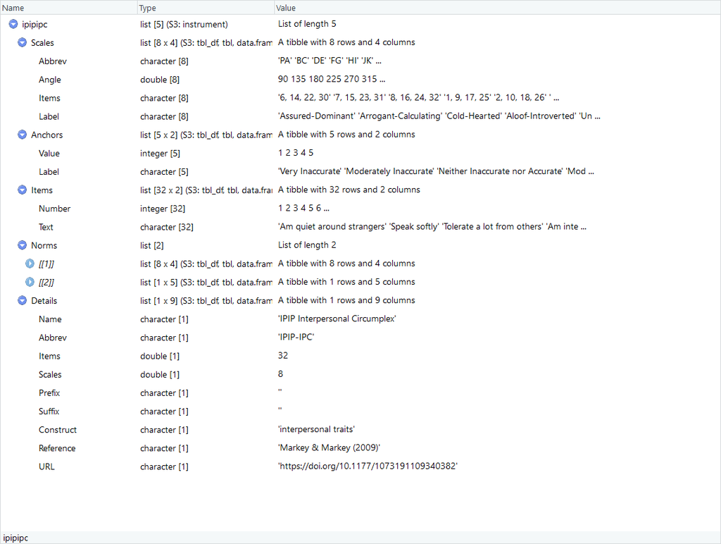

```r
View(ipipipc)
```

## 3. Instrument-related Tidying Functions

It is a good idea in practice to digitize and save each participant’s response to each item on an instrument, rather than just their scores on each scale. Having access to item-level data will make it easier to spot and correct mistakes, will enable more advanced analysis of missing data, and will enable latent variable models that account for measurement error (e.g., structural equation modeling). Furthermore, the functions described below will make it easy to transform and summarize such item-level data into scale scores.

First, however, we need to make sure the item-level data is in the expected format. Your data should be stored in a data frame where each row corresponds to one observation (e.g., participant, organization, or timepoint) and each column corresponds to one variable describing these observations (e.g., item responses, demographic characteristics, scale scores). The [tidyverse](https://www.tidyverse.org) packages provide excellent tools for getting your data into this format from a variety of different file types and formats.

For the purpose of illustration, we will work with a small-scale data set, which includes item-level responses to the Inventory of Interpersonal Problems, Short Circumplex (IIP-SC) for just 10 participants. As will become important later on, this data set contains a small amount of missing values (represented as `NA`). This data set is included as part of the circumplex package and can be loaded and previewed as follows:

```r
data("raw_iipsc")
print(raw_iipsc)
```

```
#>    IIP01 IIP02 IIP03 IIP04 IIP05 IIP06 IIP07 IIP08 IIP09 IIP10 IIP11 IIP12
#> 1      0     0     0     0     1     0     1     0     2     1     0     0
#> 2      1     1     0     0     3     2     2     1     0     1     0     1
#> 3      1     0     1     0     1     1     1     3     0     1     0     0
#> 4      3     2     3    NA     2     3     2     3     2     3     2     4
#> 5      0     0     0     1     0     0     1     1     0     1     0     2
#> 6      0     0     0     0     0     0     1     1     0     0     0     0
#> 7      1     0     0     0     2     1     1     0     1     0     0     0
#> 8      1     0     1     0     1     1     2     1     1     0     0     0
#> 9      0     0     2     2     0     1     3     0     1     0     1     1
#> 10     0     0     0     0     0     0     2     0     0     0     0     0
#>    IIP13 IIP14 IIP15 IIP16 IIP17 IIP18 IIP19 IIP20 IIP21 IIP22 IIP23 IIP24
#> 1      0     1     4     3     2     4     2     0     1     0     0     0
#> 2      4     3     3     1     0     0     1     0     1     2     0     0
#> 3      2     3     3     2     2     1     1     0     3     2     3     1
```

[output cut: 18 more lines]

### Ipsatizing item-level data

For some forms of circumplex data analysis (e.g., analysis of circumplex fit) but not others (e.g., structural summary method), it can be helpful to transform item-level responses by subtracting each participant’s mean across all items from his or her response on each item. This practice is called “ipsatizing” or, more precisely, deviation scoring across variables. This practice will attenuate the general factor across all items and recasts the item-level responses as deviations from one’s own mean rather than absolute responses. To perform ipsatizing and create a new set of ipsatized responses to each item, use the `ipsatize()` function.

```r
ips_iipsc <- ipsatize(data = raw_iipsc, items = 1:32, append = FALSE)
print(ips_iipsc)
```

```
#>       IIP01_i    IIP02_i    IIP03_i    IIP04_i    IIP05_i    IIP06_i    IIP07_i
#> 1  -1.0000000 -1.0000000 -1.0000000 -1.0000000  0.0000000 -1.0000000  0.0000000
#> 2   0.0625000  0.0625000 -0.9375000 -0.9375000  2.0625000  1.0625000  1.0625000
#> 3  -0.4062500 -1.4062500 -0.4062500 -1.4062500 -0.4062500 -0.4062500 -0.4062500
#> 4   0.7096774 -0.2903226  0.7096774         NA -0.2903226  0.7096774 -0.2903226
#> 5  -0.6250000 -0.6250000 -0.6250000  0.3750000 -0.6250000 -0.6250000  0.3750000
#> 6  -0.2812500 -0.2812500 -0.2812500 -0.2812500 -0.2812500 -0.2812500  0.7187500
#> 7   0.5000000 -0.5000000 -0.5000000 -0.5000000  1.5000000  0.5000000  0.5000000
#> 8   0.2580645 -0.7419355  0.2580645 -0.7419355  0.2580645  0.2580645  1.2580645
#> 9  -0.9687500 -0.9687500  1.0312500  1.0312500 -0.9687500  0.0312500  2.0312500
#> 10 -0.2187500 -0.2187500 -0.2187500 -0.2187500 -0.2187500 -0.2187500  1.7812500
#>       IIP08_i    IIP09_i    IIP10_i    IIP11_i    IIP12_i    IIP13_i   IIP14_i
#> 1  -1.0000000  1.0000000  0.0000000 -1.0000000 -1.0000000 -1.0000000  0.000000
#> 2   0.0625000 -0.9375000  0.0625000 -0.9375000  0.0625000  3.0625000  2.062500
#> 3   1.5937500 -1.4062500 -0.4062500 -1.4062500 -1.4062500  0.5937500  1.593750
```

[output cut: 40 more lines]

Above, we told the function to take all the variables from column 1 to column 32 and calculate new ipsatized variables ending in `_i` (although different `prefix`es and `suffix`es can be used). By default, the mean for each observation/row is calculated after ignoring any missing values, but we could have changed this by adding `na.rm = FALSE`. By setting `append` to FALSE, only the ipsatized versions are returned, but if we changed this to TRUE then the original variables would have been included as well.

We can check that the ipsatization was successful by calculating the mean of each row (i.e., each participant’s mean response) in the original and ipsatized data frames. We do this below using the `rowMeans()` function; we also apply the `round()` function to make the results fit on one row. As expected, we find below that the mean of each participant is zero in the ipsatized data frame but not in the original.

```r
round(rowMeans(raw_iipsc, na.rm = TRUE), 2)
```

```
#>  [1] 1.00 0.94 1.41 2.29 0.62 0.28 0.50 0.74 0.97 0.22
```

```r
round(rowMeans(ips_iipsc, na.rm = TRUE), 2)
```

```
#>  [1] 0 0 0 0 0 0 0 0 0 0
```

### Scoring item-level data

For many forms of circumplex data analysis (e.g., structural summary method), it can be very helpful to summarize item-level responses by calculating scale scores. This is typically done by averaging a set of items that all measure the same underlying construct (e.g., location in the circumplex model). For example, the IIP-SC has 32 items in total that measure 8 scales representing octants of the interpersonal circumplex model. Thus, a participant’s score on each scale is calculated as the arithmetic mean of his or her responses to four specific items. Using the aggregate of multiple similar items produces scale scores with higher reliability than would be achieved by using only a single item per scale.

```r
instrument("iipsc")
scales(iipsc)
```

```
#> The IIP-SC contains 8 circumplex scales.
#> PA: Domineering (90 degrees)
#> BC: Vindictive (135 degrees)
#> DE: Cold (180 degrees)
#> FG: Socially Avoidant (225 degrees)
#> HI: Nonassertive (270 degrees)
#> JK: Exploitable (315 degrees)
#> LM: Overly Nurturant (360 degrees)
#> NO: Intrusive (45 degrees)
```

Although calculating the arithmetic mean of a handful of items is not terribly difficult mathematically, doing so manually (e.g., by hand) across multiple scales and multiple participants can be tedious and error-prone. To address these issues, the circumplex package offers the `score()` function, which automatically calculates scale scores from item-level data.

To demonstrate, let’s return to the `raw_iipsc` data set. We need to give the `score()` function a data frame containing the item-level data (i.e., the data set), a list of variables from that data frame that contain the item-level responses to be scored, and an instrument object containing instructions on how to score the data. In order for scoring to work properly, **the list of items must be in ascending order from the first to the last item and the ordering of the items must be the same as that assumed by the package**. Be sure to check your item numbers against those displayed by the `items()` function, especially if you shuffle your items.

```r
scale_scores <- score(
  data = raw_iipsc,
  items = 1:32,
  instrument = iipsc,
  append = FALSE
)
print(scale_scores)
```

```
#>      PA   BC   DE       FG   HI        JK   LM   NO
#> 1  1.75 2.00 1.25 0.000000 0.50 0.2500000 1.50 0.75
#> 2  0.25 0.50 0.25 0.500000 2.00 1.7500000 1.25 1.00
#> 3  1.00 0.75 0.75 0.000000 2.25 2.0000000 2.50 2.00
#> 4  1.75 2.25 2.50 2.333333 2.50 2.0000000 2.50 2.50
#> 5  0.50 0.75 0.00 1.000000 0.50 0.2500000 1.25 0.75
#> 6  0.25 0.00 0.00 0.000000 0.00 0.0000000 1.00 1.00
#> 7  1.00 0.00 0.00 0.000000 1.00 1.0000000 0.75 0.25
#> 8  1.00 0.25 0.75 0.000000 0.50 0.6666667 1.75 1.00
#> 9  0.75 0.50 1.50 0.750000 0.00 1.0000000 2.75 0.50
#> 10 0.00 0.00 0.00 0.000000 0.00 0.5000000 1.00 0.25
```

Because we set `append` to FALSE, the `scale_scores` data frame contains only the scale score variables. These were named using the scale abbreviations shown by the `scales()` function (i.e., two-letter abbreviations from PA to NO). You can customize the naming of these variables by using the `prefix` and `suffix` arguments (e.g., to make them IIP_PA to IIP_NO).

Note that the `na.rm` argument for the `score()` function defaulted to `TRUE`, which means that missing values were ignored in calculating the scale scores. This practice is common in the literature, but is technically a form of single imputation and thus can produce biased results when data are not missing completely at random (MCAR). Please examine and report the amount and patterns of missingness in your data.

### Standardizing scale-level data

Finally, it can often be helpful to transform scale-level data through reference to a normative or comparison sample. This is often called “norm standardizing” and involves subtracting the normative sample’s mean score on a scale from each participant’s score on that scale and then dividing this difference by the normative sample’s standard deviation. This rescales the scale scores to be in standard deviation units and to describe the magnitude of each participant’s difference from the normative average.

For many circumplex instruments, the data needed to perform standardization is included in its instrument object. Some instruments even have multiple (e.g., different or overlapping) normative samples for comparisons that are matched in terms of gender, age, or nationality. In selecting a normative sample to compare to, it is important to consider both the size and the appropriateness of the sample.

To demonstrate, let’s examine the normative data sets available for the IIP-SC. Below we see that there are two options: a rather large sample of American college students and a rather small sample of American psychiatric outpatients.

```r
norms(iipsc)
```

```
#> The IIP-SC currently has 2 normative data set(s):
#> 1. 872 American college students
#> Hopwood, Pincus, DeMoor, & Koonce (2011)
#> 2. 106 American psychiatric outpatients
#> Soldz, Budman, Demby, & Merry (1995)
```

Assuming our example data also come from a non-psychiatric community sample of mostly college students, the first normative sample seems like a better choice, especially since it is so much larger and therefore subject to less sampling error. However, there may be times when the second normative sample would be the more appropriate comparison, even despite its smaller sample.

To transform the scale scores we calculated during the last section, we can call the `norm_standardize()` function and give it the `scale_scores` object we created above. We will save the output of this function to a data frame named `z_scales` to reflect the idea that standardized scores are often called “z-scores.”

```r
z_scales <- norm_standardize(
  data = scale_scores,
  scales = 1:8,
  instrument = iipsc,
  sample = 1,
  append = FALSE
)
print(z_scales)
```

```
#>           PA_z       BC_z       DE_z        FG_z       HI_z       JK_z
#> 1   1.50000000  1.7500000  0.4093567 -1.10554090 -1.0054645 -1.3313783
#> 2  -0.77272727 -0.4239130 -0.7602339 -0.57783641  0.6338798  0.4281525
#> 3   0.36363636 -0.0615942 -0.1754386 -1.10554090  0.9071038  0.7214076
#> 4   1.50000000  2.1123188  1.8713450  1.35708004  1.1803279  0.7214076
#> 5  -0.39393939 -0.0615942 -1.0526316 -0.05013193 -1.0054645 -1.3313783
#> 6  -0.77272727 -1.1485507 -1.0526316 -1.10554090 -1.5519126 -1.6246334
#> 7   0.36363636 -1.1485507 -1.0526316 -1.10554090 -0.4590164 -0.4516129
#> 8   0.36363636 -0.7862319 -0.1754386 -1.10554090 -1.0054645 -0.8426197
#> 9  -0.01515152 -0.4239130  0.7017544 -0.31398417 -1.5519126 -0.4516129
#> 10 -1.15151515 -1.1485507 -1.0526316 -1.10554090 -1.5519126 -1.0381232
#>           LM_z     NO_z
#> 1   0.04242424 -0.34375
#> 2  -0.26060606 -0.03125
#> 3   1.25454545  1.21875
#> 4   1.25454545  1.84375
#> 5  -0.26060606 -0.34375
#> 6  -0.56363636 -0.03125
#> 7  -0.86666667 -0.96875
#> 8   0.34545455 -0.03125
#> 9   1.55757576 -0.65625
#> 10 -0.56363636 -0.96875
```

Again, because we set `append` to FALSE, the output contains only the norm standardized scale-level variables. The new variables are named the same as the scale score variables except with a configurable `prefix` and `suffix` (by default, they are given only a suffix of `_z`). These variables are the ones we are most likely to use in subsequent analyses (e.g., the structural summary method).

## 4. Wrap-up

In this vignette, we learned how to preview the instruments available in the circumplex package, load and examine the information contained in one of these instrument objects, ipsatize item-level data, calculate scale scores from item-level data, and standardize those scale scores using normative data included in the package. We are now in an excellent position to discover and implement new circumplex instruments. Later vignettes describe analyses and visualizations that make use of the data collected using these tools.

Special thanks to the authors and publishers who granted permission to include information about their instruments in this package: Chloe Bliton, Michael Boudreaux, Robert Hatcher, Christopher Hopwood, Leonard Horowitz, Kenneth Locke, Patrick Markey, Aaron Pincus, Elisa Trucco, and MindGarden Inc.